# Risk Factor Analysis

## Outcome Variable

**Outcome Variable:** ever_stunted

## Predictor Variables

**Intervention Variable:** single

**Adjustment Set:**

unadjusted

## Stratifying Variables

The analysis was stratified on these variable(s):

- agecat
- studyid

The following strata were considered:

- agecat: 12 months, studyid: ki1066203-TanzaniaChild2
- agecat: 12 months, studyid: ki1112895-Guatemala BSC
- agecat: 12 months, studyid: ki1119695-PROBIT
- agecat: 12 months, studyid: ki1126311-ZVITAMBO
- agecat: 12 months, studyid: ki1135781-COHORTS
- agecat: 12 months, studyid: kiGH5241-JiVitA-4
- agecat: 18 months, studyid: ki1066203-TanzaniaChild2
- agecat: 18 months, studyid: ki1112895-Guatemala BSC
- agecat: 18 months, studyid: ki1119695-PROBIT
- agecat: 18 months, studyid: ki1126311-ZVITAMBO
- agecat: 18 months, studyid: ki1135781-COHORTS
- agecat: 18 months, studyid: kiGH5241-JiVitA-4
- agecat: 24 months, studyid: ki1066203-TanzaniaChild2
- agecat: 24 months, studyid: ki1119695-PROBIT
- agecat: 24 months, studyid: ki1126311-ZVITAMBO
- agecat: 24 months, studyid: ki1135781-COHORTS
- agecat: 24 months, studyid: kiGH5241-JiVitA-4
- agecat: 3 months, studyid: ki1066203-TanzaniaChild2
- agecat: 3 months, studyid: ki1119695-PROBIT
- agecat: 3 months, studyid: ki1126311-ZVITAMBO
- agecat: 3 months, studyid: ki1135781-COHORTS
- agecat: 3 months, studyid: kiGH5241-JiVitA-4
- agecat: 6 months, studyid: ki1066203-TanzaniaChild2
- agecat: 6 months, studyid: ki1112895-Guatemala BSC
- agecat: 6 months, studyid: ki1119695-PROBIT
- agecat: 6 months, studyid: ki1126311-ZVITAMBO
- agecat: 6 months, studyid: ki1135781-COHORTS
- agecat: 6 months, studyid: kiGH5241-JiVitA-4

## Methods Detail

# Results Detail

## Results Plots

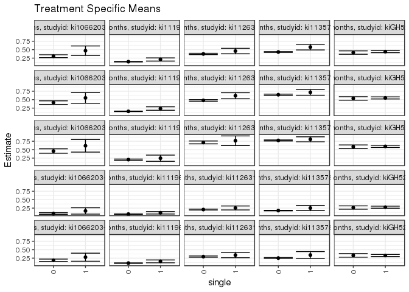

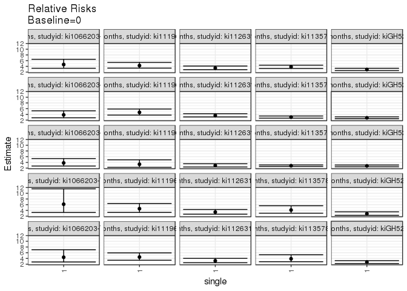

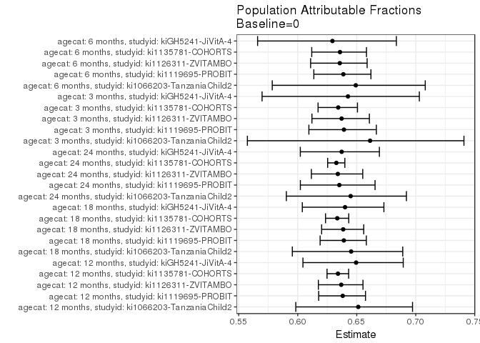

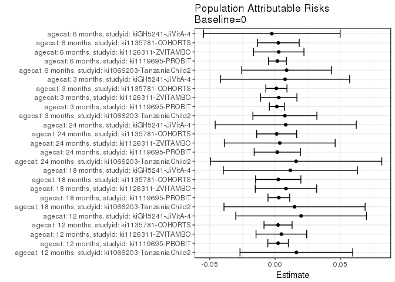

## Data Summary

| agecat | studyid | A | n | nA | nAY0 | nAY1 |
| --- | --- | --- | --- | --- | --- | --- |
| 12 months | ki1066203-TanzaniaChild2 | 0 | 491 | 442 | 307 | 135 |
| 12 months | ki1066203-TanzaniaChild2 | 1 | 491 | 49 | 26 | 23 |
| 12 months | ki1112895-Guatemala BSC | 0 | 80 | 74 | 42 | 32 |
| 12 months | ki1112895-Guatemala BSC | 1 | 80 | 6 | 2 | 4 |
| 12 months | ki1119695-PROBIT | 0 | 7943 | 7655 | 6558 | 1097 |
| 12 months | ki1119695-PROBIT | 1 | 7943 | 288 | 228 | 60 |
| 12 months | ki1126311-ZVITAMBO | 0 | 2533 | 2389 | 1498 | 891 |
| 12 months | ki1126311-ZVITAMBO | 1 | 2533 | 144 | 78 | 66 |
| 12 months | ki1135781-COHORTS | 0 | 8270 | 8138 | 4636 | 3502 |
| 12 months | ki1135781-COHORTS | 1 | 8270 | 132 | 56 | 76 |
| 12 months | kiGH5241-JiVitA-4 | 0 | 1401 | 372 | 218 | 154 |
| 12 months | kiGH5241-JiVitA-4 | 1 | 1401 | 1029 | 575 | 454 |
| 18 months | ki1066203-TanzaniaChild2 | 0 | 359 | 321 | 189 | 132 |
| 18 months | ki1066203-TanzaniaChild2 | 1 | 359 | 38 | 17 | 21 |
| 18 months | ki1112895-Guatemala BSC | 0 | 49 | 46 | 23 | 23 |
| 18 months | ki1112895-Guatemala BSC | 1 | 49 | 3 | 0 | 3 |
| 18 months | ki1119695-PROBIT | 0 | 7475 | 7214 | 6106 | 1108 |
| 18 months | ki1119695-PROBIT | 1 | 7475 | 261 | 199 | 62 |
| 18 months | ki1126311-ZVITAMBO | 0 | 1848 | 1736 | 907 | 829 |
| 18 months | ki1126311-ZVITAMBO | 1 | 1848 | 112 | 43 | 69 |
| 18 months | ki1135781-COHORTS | 0 | 3023 | 2917 | 1031 | 1886 |
| 18 months | ki1135781-COHORTS | 1 | 3023 | 106 | 30 | 76 |
| 18 months | kiGH5241-JiVitA-4 | 0 | 1353 | 362 | 168 | 194 |
| 18 months | kiGH5241-JiVitA-4 | 1 | 1353 | 991 | 444 | 547 |
| 24 months | ki1066203-TanzaniaChild2 | 0 | 250 | 224 | 121 | 103 |
| 24 months | ki1066203-TanzaniaChild2 | 1 | 250 | 26 | 10 | 16 |
| 24 months | ki1112895-Guatemala BSC | 0 | 0 | 0 | 0 | 0 |
| 24 months | ki1112895-Guatemala BSC | 1 | 0 | 0 | 0 | 0 |
| 24 months | ki1119695-PROBIT | 0 | 2076 | 1991 | 1584 | 407 |
| 24 months | ki1119695-PROBIT | 1 | 2076 | 85 | 64 | 21 |
| 24 months | ki1126311-ZVITAMBO | 0 | 469 | 435 | 124 | 311 |
| 24 months | ki1126311-ZVITAMBO | 1 | 469 | 34 | 8 | 26 |
| 24 months | ki1135781-COHORTS | 0 | 2975 | 2866 | 650 | 2216 |
| 24 months | ki1135781-COHORTS | 1 | 2975 | 109 | 21 | 88 |
| 24 months | kiGH5241-JiVitA-4 | 0 | 1181 | 319 | 132 | 187 |
| 24 months | kiGH5241-JiVitA-4 | 1 | 1181 | 862 | 347 | 515 |
| 3 months | ki1066203-TanzaniaChild2 | 0 | 595 | 535 | 486 | 49 |
| 3 months | ki1066203-TanzaniaChild2 | 1 | 595 | 60 | 50 | 10 |
| 3 months | ki1112895-Guatemala BSC | 0 | 0 | 0 | 0 | 0 |
| 3 months | ki1112895-Guatemala BSC | 1 | 0 | 0 | 0 | 0 |
| 3 months | ki1119695-PROBIT | 0 | 8125 | 7828 | 7259 | 569 |
| 3 months | ki1119695-PROBIT | 1 | 8125 | 297 | 264 | 33 |
| 3 months | ki1126311-ZVITAMBO | 0 | 3480 | 3268 | 2590 | 678 |
| 3 months | ki1126311-ZVITAMBO | 1 | 3480 | 212 | 158 | 54 |
| 3 months | ki1135781-COHORTS | 0 | 8678 | 8555 | 7037 | 1518 |
| 3 months | ki1135781-COHORTS | 1 | 8678 | 123 | 92 | 31 |
| 3 months | kiGH5241-JiVitA-4 | 0 | 1139 | 307 | 225 | 82 |
| 3 months | kiGH5241-JiVitA-4 | 1 | 1139 | 832 | 601 | 231 |
| 6 months | ki1066203-TanzaniaChild2 | 0 | 551 | 497 | 404 | 93 |
| 6 months | ki1066203-TanzaniaChild2 | 1 | 551 | 54 | 39 | 15 |
| 6 months | ki1112895-Guatemala BSC | 0 | 90 | 84 | 60 | 24 |
| 6 months | ki1112895-Guatemala BSC | 1 | 90 | 6 | 3 | 3 |
| 6 months | ki1119695-PROBIT | 0 | 7807 | 7527 | 6756 | 771 |
| 6 months | ki1119695-PROBIT | 1 | 7807 | 280 | 237 | 43 |
| 6 months | ki1126311-ZVITAMBO | 0 | 2276 | 2135 | 1506 | 629 |
| 6 months | ki1126311-ZVITAMBO | 1 | 2276 | 141 | 93 | 48 |
| 6 months | ki1135781-COHORTS | 0 | 2906 | 2824 | 2113 | 711 |
| 6 months | ki1135781-COHORTS | 1 | 2906 | 82 | 54 | 28 |
| 6 months | kiGH5241-JiVitA-4 | 0 | 1168 | 311 | 208 | 103 |
| 6 months | kiGH5241-JiVitA-4 | 1 | 1168 | 857 | 576 | 281 |

## Results Table

### Parameter: TSM

| agecat | studyid | intervention_level | baseline_level | estimate | ci_lower | ci_upper |
| --- | --- | --- | --- | --- | --- | --- |
| 12 months | ki1066203-TanzaniaChild2 | 0 | NA | 0.3054299 | 0.2624472 | 0.3484125 |
| 12 months | ki1066203-TanzaniaChild2 | 1 | NA | 0.4693878 | 0.3295104 | 0.6092651 |
| 12 months | ki1119695-PROBIT | 0 | NA | 0.1433050 | 0.1354554 | 0.1511546 |
| 12 months | ki1119695-PROBIT | 1 | NA | 0.2083333 | 0.1614272 | 0.2552395 |
| 12 months | ki1126311-ZVITAMBO | 0 | NA | 0.3729594 | 0.3535637 | 0.3923550 |
| 12 months | ki1126311-ZVITAMBO | 1 | NA | 0.4583333 | 0.3769362 | 0.5397305 |
| 12 months | ki1135781-COHORTS | 0 | NA | 0.4303269 | 0.4195690 | 0.4410848 |
| 12 months | ki1135781-COHORTS | 1 | NA | 0.5757576 | 0.4914407 | 0.6600744 |
| 12 months | kiGH5241-JiVitA-4 | 0 | NA | 0.4139785 | 0.3639085 | 0.4640485 |
| 12 months | kiGH5241-JiVitA-4 | 1 | NA | 0.4412051 | 0.4108562 | 0.4715539 |
| 18 months | ki1066203-TanzaniaChild2 | 0 | NA | 0.4112150 | 0.3573118 | 0.4651181 |
| 18 months | ki1066203-TanzaniaChild2 | 1 | NA | 0.5526316 | 0.3943201 | 0.7109431 |
| 18 months | ki1119695-PROBIT | 0 | NA | 0.1535902 | 0.1452695 | 0.1619110 |
| 18 months | ki1119695-PROBIT | 1 | NA | 0.2375479 | 0.1859135 | 0.2891822 |
| 18 months | ki1126311-ZVITAMBO | 0 | NA | 0.4775346 | 0.4540316 | 0.5010375 |
| 18 months | ki1126311-ZVITAMBO | 1 | NA | 0.6160714 | 0.5259771 | 0.7061657 |
| 18 months | ki1135781-COHORTS | 0 | NA | 0.6465547 | 0.6292040 | 0.6639053 |
| 18 months | ki1135781-COHORTS | 1 | NA | 0.7169811 | 0.6312125 | 0.8027498 |
| 18 months | kiGH5241-JiVitA-4 | 0 | NA | 0.5359116 | 0.4845189 | 0.5873043 |
| 18 months | kiGH5241-JiVitA-4 | 1 | NA | 0.5519677 | 0.5209947 | 0.5829407 |
| 24 months | ki1066203-TanzaniaChild2 | 0 | NA | 0.4598214 | 0.3944244 | 0.5252184 |
| 24 months | ki1066203-TanzaniaChild2 | 1 | NA | 0.6153846 | 0.4280067 | 0.8027625 |
| 24 months | ki1119695-PROBIT | 0 | NA | 0.2044199 | 0.1867016 | 0.2221381 |
| 24 months | ki1119695-PROBIT | 1 | NA | 0.2470588 | 0.1553473 | 0.3387704 |
| 24 months | ki1126311-ZVITAMBO | 0 | NA | 0.7149425 | 0.6724739 | 0.7574112 |
| 24 months | ki1126311-ZVITAMBO | 1 | NA | 0.7647059 | 0.6219727 | 0.9074390 |
| 24 months | ki1135781-COHORTS | 0 | NA | 0.7732031 | 0.7578693 | 0.7885368 |
| 24 months | ki1135781-COHORTS | 1 | NA | 0.8073394 | 0.7332882 | 0.8813907 |
| 24 months | kiGH5241-JiVitA-4 | 0 | NA | 0.5862069 | 0.5321372 | 0.6402766 |
| 24 months | kiGH5241-JiVitA-4 | 1 | NA | 0.5974478 | 0.5646957 | 0.6301999 |
| 3 months | ki1066203-TanzaniaChild2 | 0 | NA | 0.0915888 | 0.0671264 | 0.1160512 |
| 3 months | ki1066203-TanzaniaChild2 | 1 | NA | 0.1666667 | 0.0722885 | 0.2610448 |
| 3 months | ki1119695-PROBIT | 0 | NA | 0.0726878 | 0.0669361 | 0.0784394 |
| 3 months | ki1119695-PROBIT | 1 | NA | 0.1111111 | 0.0753674 | 0.1468548 |
| 3 months | ki1126311-ZVITAMBO | 0 | NA | 0.2074663 | 0.1935619 | 0.2213707 |
| 3 months | ki1126311-ZVITAMBO | 1 | NA | 0.2547170 | 0.1960583 | 0.3133756 |
| 3 months | ki1135781-COHORTS | 0 | NA | 0.1774401 | 0.1693441 | 0.1855361 |
| 3 months | ki1135781-COHORTS | 1 | NA | 0.2520325 | 0.1752981 | 0.3287669 |
| 3 months | kiGH5241-JiVitA-4 | 0 | NA | 0.2671010 | 0.2175868 | 0.3166151 |
| 3 months | kiGH5241-JiVitA-4 | 1 | NA | 0.2776442 | 0.2472006 | 0.3080879 |
| 6 months | ki1066203-TanzaniaChild2 | 0 | NA | 0.1871227 | 0.1528033 | 0.2214422 |
| 6 months | ki1066203-TanzaniaChild2 | 1 | NA | 0.2777778 | 0.1582057 | 0.3973499 |
| 6 months | ki1119695-PROBIT | 0 | NA | 0.1024312 | 0.0955809 | 0.1092816 |
| 6 months | ki1119695-PROBIT | 1 | NA | 0.1535714 | 0.1113389 | 0.1958040 |
| 6 months | ki1126311-ZVITAMBO | 0 | NA | 0.2946136 | 0.2752723 | 0.3139548 |
| 6 months | ki1126311-ZVITAMBO | 1 | NA | 0.3404255 | 0.2621949 | 0.4186562 |
| 6 months | ki1135781-COHORTS | 0 | NA | 0.2517705 | 0.2357598 | 0.2677812 |
| 6 months | ki1135781-COHORTS | 1 | NA | 0.3414634 | 0.2388089 | 0.4441179 |
| 6 months | kiGH5241-JiVitA-4 | 0 | NA | 0.3311897 | 0.2788605 | 0.3835189 |
| 6 months | kiGH5241-JiVitA-4 | 1 | NA | 0.3278880 | 0.2964447 | 0.3593312 |

### Parameter: E(Y)

| agecat | studyid | intervention_level | baseline_level | estimate | ci_lower | ci_upper |
| --- | --- | --- | --- | --- | --- | --- |
| 12 months | ki1066203-TanzaniaChild2 | NA | NA | 0.3217923 | 0.3174411 | 0.3261435 |
| 12 months | ki1119695-PROBIT | NA | NA | 0.1456628 | 0.1453955 | 0.1459302 |
| 12 months | ki1126311-ZVITAMBO | NA | NA | 0.3778129 | 0.3770429 | 0.3785829 |
| 12 months | ki1135781-COHORTS | NA | NA | 0.4326481 | 0.4322553 | 0.4330410 |
| 12 months | kiGH5241-JiVitA-4 | NA | NA | 0.4339757 | 0.4333459 | 0.4346056 |
| 18 months | ki1066203-TanzaniaChild2 | NA | NA | 0.4261838 | 0.4216772 | 0.4306905 |
| 18 months | ki1119695-PROBIT | NA | NA | 0.1565217 | 0.1561723 | 0.1568711 |
| 18 months | ki1126311-ZVITAMBO | NA | NA | 0.4859307 | 0.4844232 | 0.4874383 |
| 18 months | ki1135781-COHORTS | NA | NA | 0.6490241 | 0.6485623 | 0.6494860 |
| 18 months | kiGH5241-JiVitA-4 | NA | NA | 0.5476718 | 0.5472930 | 0.5480507 |
| 24 months | ki1066203-TanzaniaChild2 | NA | NA | 0.4760000 | 0.4701017 | 0.4818983 |
| 24 months | ki1119695-PROBIT | NA | NA | 0.2061657 | 0.2058022 | 0.2065293 |
| 24 months | ki1126311-ZVITAMBO | NA | NA | 0.7185501 | 0.7173810 | 0.7197192 |
| 24 months | ki1135781-COHORTS | NA | NA | 0.7744538 | 0.7742233 | 0.7746843 |
| 24 months | kiGH5241-JiVitA-4 | NA | NA | 0.5944115 | 0.5941267 | 0.5946963 |
| 3 months | ki1066203-TanzaniaChild2 | NA | NA | 0.0991597 | 0.0973416 | 0.1009777 |
| 3 months | ki1119695-PROBIT | NA | NA | 0.0740923 | 0.0739355 | 0.0742491 |
| 3 months | ki1126311-ZVITAMBO | NA | NA | 0.2103448 | 0.2099693 | 0.2107204 |
| 3 months | ki1135781-COHORTS | NA | NA | 0.1784973 | 0.1783118 | 0.1786829 |
| 3 months | kiGH5241-JiVitA-4 | NA | NA | 0.2748025 | 0.2745307 | 0.2750743 |
| 6 months | ki1066203-TanzaniaChild2 | NA | NA | 0.1960073 | 0.1937547 | 0.1982598 |
| 6 months | ki1119695-PROBIT | NA | NA | 0.1042654 | 0.1040544 | 0.1044764 |
| 6 months | ki1126311-ZVITAMBO | NA | NA | 0.2974517 | 0.2969979 | 0.2979055 |
| 6 months | ki1135781-COHORTS | NA | NA | 0.2543014 | 0.2537613 | 0.2548415 |
| 6 months | kiGH5241-JiVitA-4 | NA | NA | 0.3287671 | 0.3286834 | 0.3288509 |

### Parameter: RR

| agecat | studyid | intervention_level | baseline_level | estimate | ci_lower | ci_upper |
| --- | --- | --- | --- | --- | --- | --- |
| 12 months | ki1066203-TanzaniaChild2 | 1 | 0 | 4.649735 | 3.344284 | 6.464773 |
| 12 months | ki1119695-PROBIT | 1 | 0 | 4.279240 | 3.394168 | 5.395106 |
| 12 months | ki1126311-ZVITAMBO | 1 | 0 | 3.417501 | 2.840153 | 4.112212 |
| 12 months | ki1135781-COHORTS | 1 | 0 | 3.811238 | 3.285079 | 4.421671 |
| 12 months | kiGH5241-JiVitA-4 | 1 | 0 | 2.903068 | 2.525977 | 3.336453 |
| 18 months | ki1066203-TanzaniaChild2 | 1 | 0 | 3.833965 | 2.797888 | 5.253708 |
| 18 months | ki1119695-PROBIT | 1 | 0 | 4.695638 | 3.753244 | 5.874656 |
| 18 months | ki1126311-ZVITAMBO | 1 | 0 | 3.633181 | 3.113690 | 4.239344 |
| 18 months | ki1135781-COHORTS | 1 | 0 | 3.031100 | 2.681370 | 3.426446 |
| 18 months | kiGH5241-JiVitA-4 | 1 | 0 | 2.800955 | 2.506411 | 3.130113 |
| 24 months | ki1066203-TanzaniaChild2 | 1 | 0 | 3.812603 | 2.724392 | 5.335481 |
| 24 months | ki1119695-PROBIT | 1 | 0 | 3.348743 | 2.287334 | 4.902686 |
| 24 months | ki1126311-ZVITAMBO | 1 | 0 | 2.914227 | 2.395829 | 3.544794 |
| 24 months | ki1135781-COHORTS | 1 | 0 | 2.840981 | 2.586505 | 3.120494 |
| 24 months | kiGH5241-JiVitA-4 | 1 | 0 | 2.770910 | 2.488992 | 3.084759 |
| 3 months | ki1066203-TanzaniaChild2 | 1 | 0 | 6.170179 | 3.299039 | 11.540063 |
| 3 months | ki1119695-PROBIT | 1 | 0 | 4.611751 | 3.311250 | 6.423027 |
| 3 months | ki1126311-ZVITAMBO | 1 | 0 | 3.413543 | 2.685608 | 4.338786 |
| 3 months | ki1135781-COHORTS | 1 | 0 | 4.138697 | 3.042011 | 5.630753 |
| 3 months | kiGH5241-JiVitA-4 | 1 | 0 | 2.827726 | 2.279818 | 3.507313 |
| 6 months | ki1066203-TanzaniaChild2 | 1 | 0 | 4.412619 | 2.763686 | 7.045375 |
| 6 months | ki1119695-PROBIT | 1 | 0 | 4.478389 | 3.374495 | 5.943400 |
| 6 months | ki1126311-ZVITAMBO | 1 | 0 | 3.175606 | 2.500529 | 4.032935 |
| 6 months | ki1135781-COHORTS | 1 | 0 | 3.881604 | 2.854696 | 5.277918 |
| 6 months | kiGH5241-JiVitA-4 | 1 | 0 | 2.691317 | 2.237151 | 3.237684 |

### Parameter: PAR

| agecat | studyid | intervention_level | baseline_level | estimate | ci_lower | ci_upper |
| --- | --- | --- | --- | --- | --- | --- |
| 12 months | ki1066203-TanzaniaChild2 | 0 | NA | 0.0163624 | -0.0268400 | 0.0595648 |
| 12 months | ki1119695-PROBIT | 0 | NA | 0.0023578 | -0.0054963 | 0.0102120 |
| 12 months | ki1126311-ZVITAMBO | 0 | NA | 0.0048535 | -0.0145575 | 0.0242644 |
| 12 months | ki1135781-COHORTS | 0 | NA | 0.0023213 | -0.0084438 | 0.0130863 |
| 12 months | kiGH5241-JiVitA-4 | 0 | NA | 0.0199972 | -0.0300767 | 0.0700712 |
| 18 months | ki1066203-TanzaniaChild2 | 0 | NA | 0.0149689 | -0.0391223 | 0.0690601 |
| 18 months | ki1119695-PROBIT | 0 | NA | 0.0029315 | -0.0053966 | 0.0112596 |
| 18 months | ki1126311-ZVITAMBO | 0 | NA | 0.0083962 | -0.0151551 | 0.0319474 |
| 18 months | ki1135781-COHORTS | 0 | NA | 0.0024695 | -0.0148873 | 0.0198263 |
| 18 months | kiGH5241-JiVitA-4 | 0 | NA | 0.0117602 | -0.0396338 | 0.0631543 |
| 24 months | ki1066203-TanzaniaChild2 | 0 | NA | 0.0161786 | -0.0494839 | 0.0818410 |
| 24 months | ki1119695-PROBIT | 0 | NA | 0.0017458 | -0.0159762 | 0.0194678 |
| 24 months | ki1126311-ZVITAMBO | 0 | NA | 0.0036076 | -0.0388772 | 0.0460923 |
| 24 months | ki1135781-COHORTS | 0 | NA | 0.0012507 | -0.0140848 | 0.0165862 |
| 24 months | kiGH5241-JiVitA-4 | 0 | NA | 0.0082046 | -0.0458658 | 0.0622750 |
| 3 months | ki1066203-TanzaniaChild2 | 0 | NA | 0.0075709 | -0.0169590 | 0.0321007 |
| 3 months | ki1119695-PROBIT | 0 | NA | 0.0014045 | -0.0043493 | 0.0071583 |
| 3 months | ki1126311-ZVITAMBO | 0 | NA | 0.0028785 | -0.0110310 | 0.0167880 |
| 3 months | ki1135781-COHORTS | 0 | NA | 0.0010573 | -0.0070409 | 0.0091554 |
| 3 months | kiGH5241-JiVitA-4 | 0 | NA | 0.0077015 | -0.0418134 | 0.0572164 |
| 6 months | ki1066203-TanzaniaChild2 | 0 | NA | 0.0088845 | -0.0255088 | 0.0432778 |
| 6 months | ki1119695-PROBIT | 0 | NA | 0.0018342 | -0.0050195 | 0.0086878 |
| 6 months | ki1126311-ZVITAMBO | 0 | NA | 0.0028381 | -0.0165085 | 0.0221847 |
| 6 months | ki1135781-COHORTS | 0 | NA | 0.0025309 | -0.0134889 | 0.0185507 |
| 6 months | kiGH5241-JiVitA-4 | 0 | NA | -0.0024226 | -0.0547518 | 0.0499066 |

### Parameter: PAF

| agecat | studyid | intervention_level | baseline_level | estimate | ci_lower | ci_upper |
| --- | --- | --- | --- | --- | --- | --- |
| 12 months | ki1066203-TanzaniaChild2 | 0 | NA | 0.6513099 | 0.5983584 | 0.6972804 |
| 12 months | ki1119695-PROBIT | 0 | NA | 0.6381238 | 0.6177372 | 0.6574231 |
| 12 months | ki1126311-ZVITAMBO | 0 | NA | 0.6368769 | 0.6174779 | 0.6552922 |
| 12 months | ki1135781-COHORTS | 0 | NA | 0.6340996 | 0.6248309 | 0.6431394 |
| 12 months | kiGH5241-JiVitA-4 | 0 | NA | 0.6494686 | 0.6043986 | 0.6894039 |
| 18 months | ki1066203-TanzaniaChild2 | 0 | NA | 0.6452712 | 0.5954149 | 0.6889837 |
| 18 months | ki1119695-PROBIT | 0 | NA | 0.6390755 | 0.6189656 | 0.6581240 |
| 18 months | ki1126311-ZVITAMBO | 0 | NA | 0.6385322 | 0.6202596 | 0.6559256 |
| 18 months | ki1135781-COHORTS | 0 | NA | 0.6335230 | 0.6235517 | 0.6432302 |
| 18 months | kiGH5241-JiVitA-4 | 0 | NA | 0.6401055 | 0.6038824 | 0.6730162 |
| 24 months | ki1066203-TanzaniaChild2 | 0 | NA | 0.6448391 | 0.5903381 | 0.6920894 |
| 24 months | ki1119695-PROBIT | 0 | NA | 0.6352490 | 0.6022162 | 0.6655387 |
| 24 months | ki1126311-ZVITAMBO | 0 | NA | 0.6339722 | 0.6115622 | 0.6550893 |
| 24 months | ki1135781-COHORTS | 0 | NA | 0.6327151 | 0.6253578 | 0.6399280 |
| 24 months | kiGH5241-JiVitA-4 | 0 | NA | 0.6372336 | 0.6021811 | 0.6691975 |
| 3 months | ki1066203-TanzaniaChild2 | 0 | NA | 0.6613072 | 0.5573358 | 0.7408581 |
| 3 months | ki1119695-PROBIT | 0 | NA | 0.6391607 | 0.6094370 | 0.6666223 |
| 3 months | ki1126311-ZVITAMBO | 0 | NA | 0.6371894 | 0.6120313 | 0.6607162 |
| 3 months | ki1135781-COHORTS | 0 | NA | 0.6343060 | 0.6172295 | 0.6506207 |
| 3 months | kiGH5241-JiVitA-4 | 0 | NA | 0.6425764 | 0.5697784 | 0.7030562 |
| 6 months | ki1066203-TanzaniaChild2 | 0 | NA | 0.6491792 | 0.5784066 | 0.7080712 |
| 6 months | ki1119695-PROBIT | 0 | NA | 0.6386493 | 0.6136446 | 0.6620356 |
| 6 months | ki1126311-ZVITAMBO | 0 | NA | 0.6356474 | 0.6109183 | 0.6588048 |
| 6 months | ki1135781-COHORTS | 0 | NA | 0.6358001 | 0.6118737 | 0.6582515 |
| 6 months | kiGH5241-JiVitA-4 | 0 | NA | 0.6294197 | 0.5659873 | 0.6835813 |